# Data Examples

Lacey Etzkorn

5/4/2020

For the multivariate recurrent event model with two terminal endpoints, a number of cases might be difficult to define in the data.

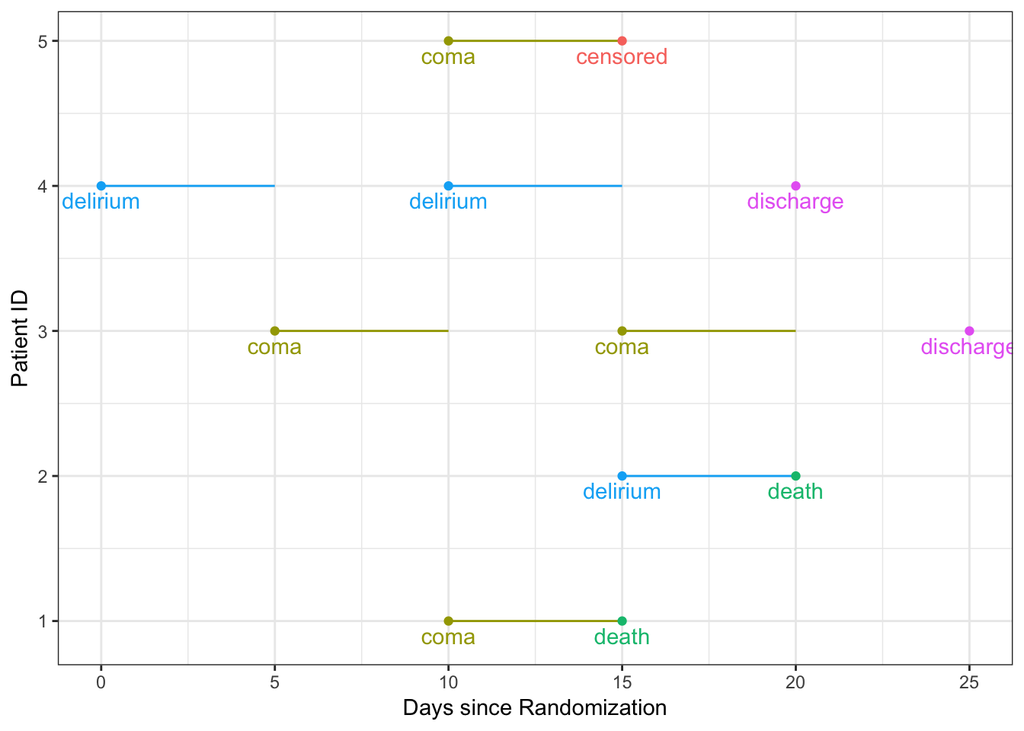

Furthermore, if we were modelling both delirium and coma, it would be difficult to indicate in a data set that individual 2 was at risk for coma for the last 5 days, but not individual 1.

# Data Organization for One Recurrent Event

The idea is to take a data frame we would use for the terminal events and a separate data frame we would use for the recurrent events, and just “stack” them, where the new variable “risk” corresponds to which data frame the entry came from. We call it “risk” to denote the person is “at risk” for a given event.

Organizing the data this way allows us to know exactly which periods a person was at risk for delirium. Otherwise for person 1, we might have thought they were at risk again from day 10 through day 15.

```
##    id t0 t1     risk delirium death discharge
## 1   1  0 10 delirium        0     0         0
## 2   1  0 15 terminal        0     1         0
## 3   2  0 15 delirium        1     0         0
## 4   2  0 20 terminal        0     1         0
## 5   3  0  5 delirium        0     0         0
## 6   3 10 15 delirium        0     0         0
## 7   3 20 25 delirium        0     0         0
## 8   3  0 25 terminal        0     0         1
## 9   4  0  0 delirium        1     0         0
## 10  4  5 10 delirium        1     0         0
## 11  4 15 20 delirium        0     0         0
## 12  4  0 20 terminal        0     0         1
```

The risk column tells us which event the period from `t0` to `t1` corresponds to. The three indicators `delirium`, `death`, and `discharge` tell us which event (if any) occurred. If no events occured, then we can assume that the risk period was terminated by another censoring mechanism (coma).

# Data Organization for Two Recurrent Events

Again, the idea is to take a data frame we would use for the terminal events and a separate data frame we would use for the recurrent events, and just “stack” them.

It is important to contrast IDs 3 and 4, because each had two episodes: ID 3 had two episodes of coma, and ID 4 had two episodes of delirium. HOWEVER, their data looks very different because coma censors the delirium process for person 3, creating 3 disjoint at risk periods for delirium and coma. In comparison, delirium does not censor the coma process, to there is only one continuous at risk period for person 4 despite person 4 having 3 disjoint at risk periods for delirium.

[output not shown]

# Virginie’s solution

```r
##    ID T0   T1  GAP DELIR death discharge
## 1   1  0 10.0 10.0     0     0         0
## 2   1 15 15.1  0.1     0     1         0
## 3   2  0 15.0 15.0     1     0         0
## 4   2 20 20.1  0.1     0     1         0
## 5   3  0  5.0  5.0     0     0         0
## 6   3 10 15.0 15.0     0     0         0
## 7   3 20 25.0  5.0     0     0         1
## 8   4  0  0.1  0.1     1     0         0
## 9   4  5 10.0  5.0     1     0         0
## 10  4 15 20.0  5.0     0     0         1

##   ID T0   T1  GAP COMA death discharge
## 1  1  0 10.0 10.0    0     0         0
## 2  1 15 15.1  0.1    0     1         0
## 3  2  0 20.1 20.1    0     1         0
## 4  3  0  5.0  5.0    1     0         0
## 5  3 10 15.0  5.0    1     0         0
## 6  3 20 25.0  5.0    0     0         1
## 7  4  0 20.0 20.0    0     0         1
```

I think this solution is ok, but I still prefer mine, because then there is only one authoritative representation of the terminal events for each person. If we split the data across two data frames, then we would need to make sure that each person’s terminal event data matched across both data frames, and that the user did not screw anything up.

Another alternate solution would be to use three data frames. This way the user cannot have conflicting information about terminal events.

```r
# Delirum Data Frame
##    ID T0   T1  GAP DELIR
## 1   1  0 10.0 10.0     0
## 2   1 15 15.1  0.1     0
## 3   2  0 15.0 15.0     1
## 4   2 20 20.1  0.1     0
## 5   3  0  5.0  5.0     0
## 6   3 10 15.0 15.0     0
## 7   3 20 25.0  5.0     0
## 8   4  0  0.1  0.1     1
## 9   4  5 10.0  5.0     1
## 10  4 15 20.0  5.0     0
## 11  5  0 10.0 10.0     0
## 12  5 15 15.1  0.1     0

# Coma Data Frame
##   ID T0   T1  GAP COMA
## 1  1  0 10.0 10.0    1
## 2  1 15 15.1  0.1    0
## 3  2  0 20.1 20.1    0
## 4  3  0  5.0  5.0    1
## 5  3 10 15.0  5.0    1
## 6  3 20 25.0  5.0    0
## 7  4  0 20.0 20.0    0
##    5  0 10.0 10.0    1
##    5 15 15.1  0.1    0

# Terminal Data Frame
##   ID T0   T1  GAP death discharge
## 2  1 15 15.1  0.1     1         0
## 3  2  0 20.1 20.1     1         0
## 6  3 20 25.0  5.0     0         1
## 7  4  0 20.0 20.0     0         1
##    5  0 20.0 20.0     0         0
```